# xwMOOC 네트워크

상관분석

# 1. 탐색적 데이터 분석 [^1]

놀이공원 방문에 대한 만족도 조사를 한 데이터가 [rintro-chapter7.csv](http://r-marketing.r-forge.r-project.org/data/) 파일에 저장되어 있다. 이 파일을 다운로드 받아 탐색적 데이터 분석을 수행한다. 단, 빠르고 신속해야만 한다.

## 1.1. 놀이공원 데이터

[rintro-chapter7.csv](http://r-marketing.r-forge.r-project.org/data/) 파일을 `read_csv()` 함수로 불러읽어 들인다. 그리고 데이터가 크지 않아 100개만 뽑아서 살펴보자.

```r
# 0. 환경설정 ------------------

library(tidygraph)
library(tidyverse)
library(ggraph)
library(DT)
library(corrplot)
library(GGally)
library(skimr)
library(corrr)
library(extrafont)
loadfonts()

# 1. 데이터 가져오기 ------------------
market_df <- read_csv("http://r-marketing.r-forge.r-project.org/data/rintro-chapter7.csv")
market_df %>% sample_n(100) %>% datatable()
```

|  | weekend | num.child | distance | rides | games | wait | clean | overall |
| --- | --- | --- | --- | --- | --- | --- | --- | --- |
| 1 | no | 5 | 70.904421921021 | 83 | 92 | 76 | 93 | 72 |
| 2 | no | 4 | 30.0693022560221 | 88 | 73 | 62 | 88 | 58 |
| 3 | no | 2 | 85.0180163200213 | 81 | 70 | 64 | 85 | 46 |
| 4 | yes | 1 | 2.92255381492077 | 86 | 82 | 61 | 90 | 39 |
| 5 | no | 2 | 35.3970131138858 | 95 | 89 | 81 | 99 | 79 |
| 6 | no | 1 | 239.192133707289 | 85 | 82 | 63 | 87 | 52 |
| 7 | yes | 2 | 13.4536804713751 | 87 | 84 | 75 | 91 | 51 |
| 8 | no | 0 | 23.8763070000187 | 82 | 71 | 69 | 80 | 37 |
| 9 | no | 2 | 37.5006966494277 | 89 | 86 | 82 | 94 | 66 |
| 10 | yes | 0 | 18.3407046741786 | 84 | 81 | 71 | 89 | 39 |

[output cut: 90 more lines]

## 1.1. 단변량 분석

`skim()` 함수를 통해서 단변량 데이터 분석을 신속히 수행한다.

```r
# 2. 탐색적 데이터 분석 ------------------
## 2.1. 단변량 분석 ------------------
skim(market_df)
```

```
Skim summary statistics
 n obs: 500
 n variables: 8

Variable type: character
 variable missing complete   n min max empty n_unique
  weekend       0      500 500   2   3     0        2

Variable type: integer
  variable missing complete   n  mean    sd p0 p25 median p75 p100
     clean       0      500 500 87.9   5.12 74  84     88  91  100
     games       0      500 500 78.67  8.12 57  73     78  85  100
 num.child       0      500 500  1.74  1.5   0   0      2   3    5
   overall       0      500 500 51.26 15.88  6  40     50  62  100
     rides       0      500 500 85.85  5.46 72  82     86  90  100
      wait       0      500 500 69.9  10.77 40  62     70  77  100
     hist
 ▁▂▅▇▆▆▂▂
 ▁▂▇▇▇▇▂▁
 ▇▃▁▇▃▁▂▁
 ▁▂▅▇▅▅▁▁
 ▁▃▃▇▆▅▂▁
 ▁▂▆▇▇▆▂▁

Variable type: numeric
 variable missing complete   n  mean    sd   p0   p25 median   p75   p100
 distance       0      500 500 31.05 33.15 0.53 10.32  19.02 39.58 239.19
     hist
 ▇▂▁▁▁▁▁▁
```

## 1.2. 교차분석

`ggpairs()` 함수로 모든 변수에 대해서 교차분석을 수행한다.

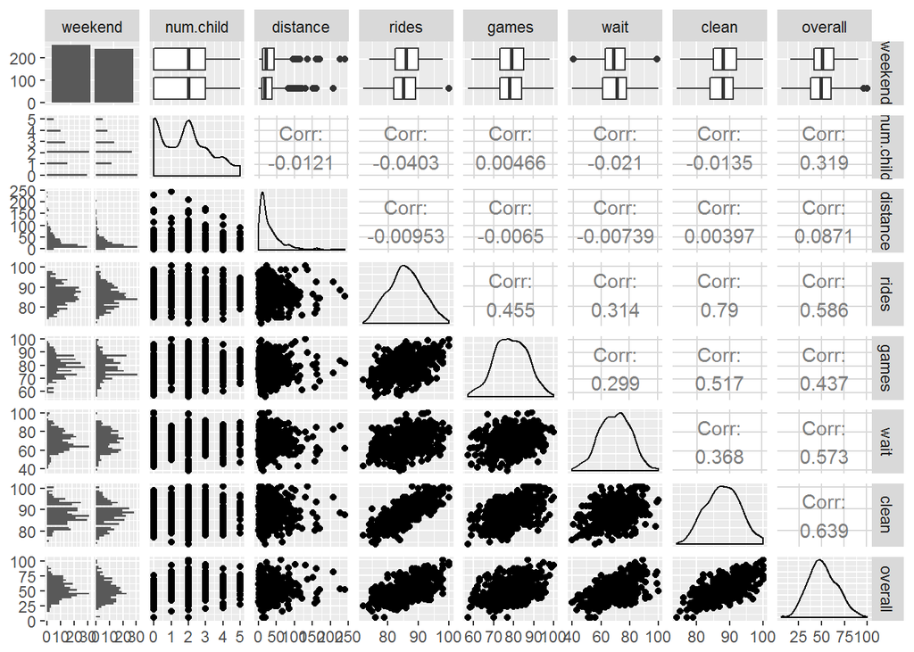

```r
## 2.2. 교차 분석 ------------------
ggpairs(market_df)
```

## 1.3. 상관분석

`corrplot.mixed()` 함수로 모든 변수에 대해서 중요 변수에 대해 상관분석을 수행한다.

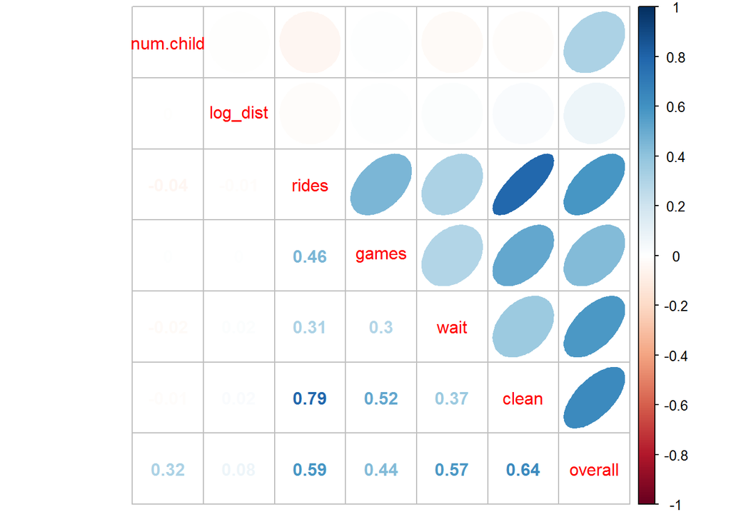

```r
## 2.3. 상관 분석 ------------------
market_df %>%
  mutate(log_dist = log(distance)) %>%
  select(num.child, log_dist, rides, games, wait, clean, overall) %>%
  cor() %>%
  corrplot.mixed(upper="ellipse")
```

# 2. 상관계수 네트워크 분석

## 2.1. 상관계수 기반 네트워크 분석 데이터프레임

상관계수 기반 네트워크 분석을 위해서 `corrr` 팩키지를 활용한다. 기존 `cor()` 함수는 데이터 상관계수 분석 결과가 행렬로 떨어지게 되어 다음 분석단계에서 활용시 애로사항이 많았다. [corrr](https://github.com/drsimonj/corrr/) 팩키지는 후속 분석이 용이하도록 다양한 함수도 제공한다.

```r
# 3. 네트워크 분석 ------------------
## 3.1. 상관분석 행렬 --> 데이터프레임 데이터
market_cor_df <- market_df %>%
  mutate(log_dist = log(distance)) %>%
  select(num.child, log_dist, rides, games, wait, clean, overall) %>%
  t() %>% correlate() %>% # (2)
  shave(upper = TRUE) %>% # (3)
  stretch(na.rm = TRUE) %>%
  filter(r >=0.9993)
```

## 2.2. 상관계수 기반 네트워크 분석 시각화

상관계수는 두변수 간의 관계로 방향성이 없이 두변수간의 상관계수를 `corrr` 팩키지 `stretch()` 함수로 구현하였다. 이를 `tidygraph` 인자로 넣어 네트워크 자료형을 변환시킨 후에 `ggraph()` 함수로 시각화한다.

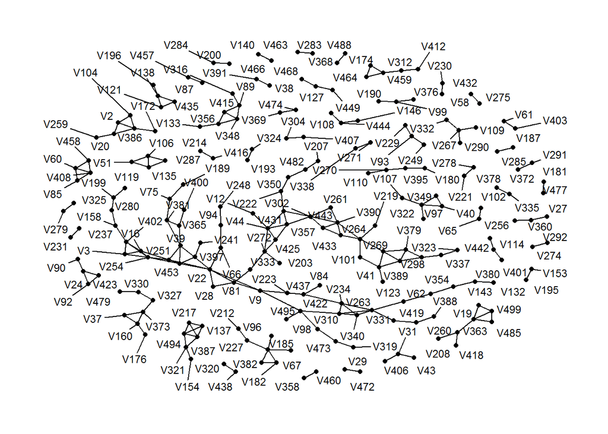

```r
## 3.2. 네트워크 시각화
### 3.2.1. 초기 시각화 -----
market_graph <- as_tbl_graph(market_cor_df, directed = FALSE)

ggraph(market_graph) +
  geom_edge_link() +
  geom_node_point() +
  geom_node_text(aes(label = name), size = 3, repel = TRUE) +
  theme_graph(base_family="NanumGothic")
```

## 2.3. 상관계수 기반 네트워크 고급 시각화

네트워크 분석에서 결점 노드는 범주형, 연결선 엣지는 숫자형 가중치(`weight`)를 사용하여 이를 네트워크 그래프에 반영시킨다.

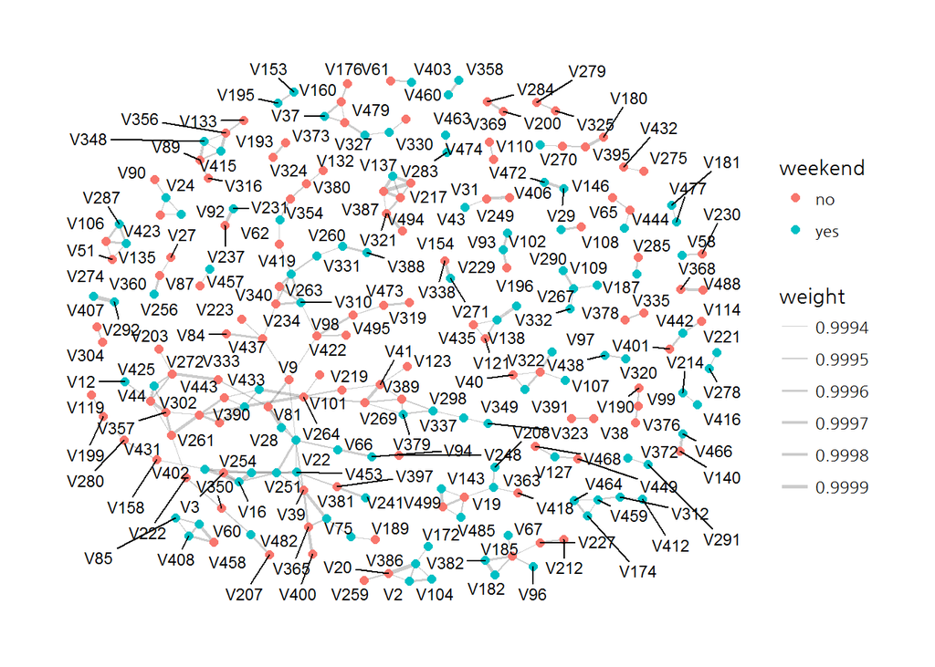

```r
### 3.2.2. 주말 효과 -----
# 주말 효과
weekend_df <- data_frame(
  name = paste0("V",rownames(market_df)),
  weekend = as.factor(market_df$weekend)
)

market_graph <- market_graph %>%
  activate(nodes) %>%
  left_join(weekend_df, by = "name")

# 연결선 가중치(weight)
market_graph <- market_graph %>%
  activate(edges) %>%
  rename(weight = r)

# 시각화
ggraph(market_graph) +
  geom_edge_link(aes(width = weight), alpha = 0.2) +
  scale_edge_width(range = c(0.2, 1)) +
  geom_node_point(aes(color = weekend), size = 2) +
  geom_node_text(aes(label = name), size = 3, repel = TRUE) +
  theme_graph(base_family="NanumGothic")
```

# 3. 군집분석

`tidygraph` 팩키지에 다수 군집분석관련된 함수가 지원되는데 `group_*`로 시작한다. `group_infomap()`, `group_edge_betweenness()` 함수가 대표적이다. 이를 반영하여 군집을 식별하고 시각화한다.

[figure not shown]

```r
# 4. 군집분석 ------------------
market_graph %>%
  activate(nodes) %>%
  mutate(community = as.factor(group_infomap())) %>%
  mutate(community = fct_lump(community, 5)) %>%
  ggraph(layout = "graphopt") +
  geom_edge_link(width = 1, colour = "lightgray") +
  geom_node_point(aes(color = community), size = 2) +
  geom_node_text(aes(label = name), size = 3, repel = TRUE) +
  theme_graph(base_family="NanumGothic")
```

[^1]: [R for Marketing Research and Analytics by Chris Chapman and Elea McDonnell Feit](http://r-marketing.r-forge.r-project.org/index.html)